# McNally et al. Larval Biomineralization

# Visualize variance among families: Calcification

Right now this is using the mean for each jar (not all larvae measured could do that with LarvaeDat)

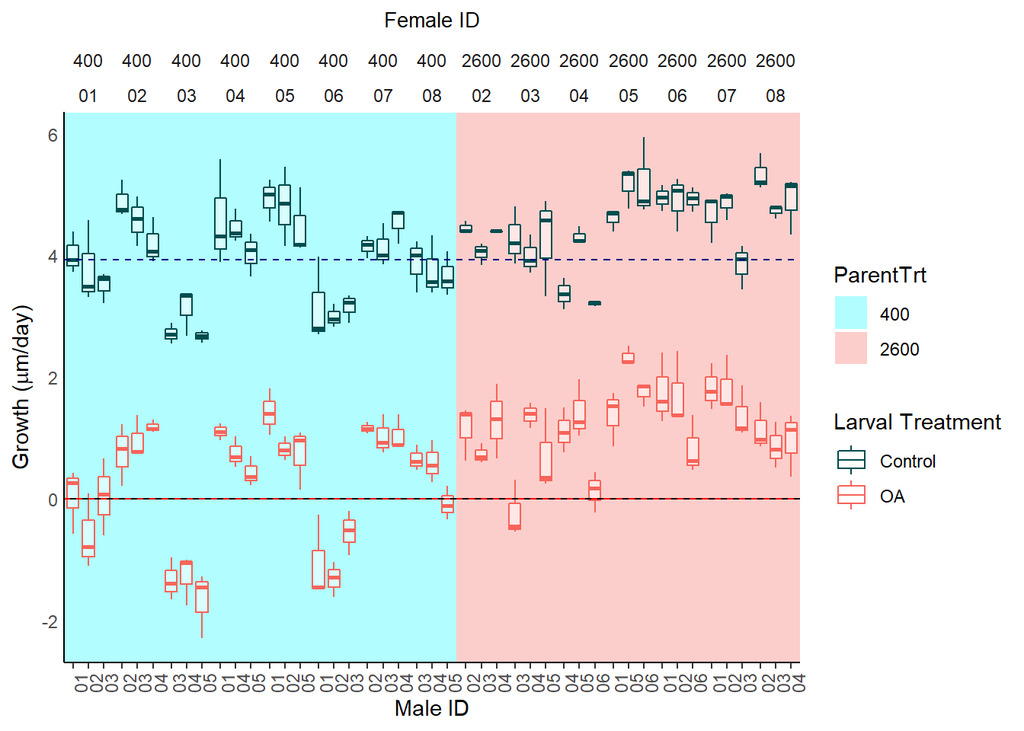

```r
#pull means for the control larvae control parents
ConConMeans<- meanJarTrt %>%
  filter(JarTrt=="Control" & ParentTrt=="400") %>%
  subset(select= c("MeanGPD", "LarvaePerimeterum", "LarvaeAreaum2",  "LarvaeDiamum"))
ConExpMeans<- meanJarTrt %>%
  filter(JarTrt=="Exposed" & ParentTrt=="400") %>%
  subset(select= c("MeanGPD", "LarvaePerimeterum", "LarvaeAreaum2",  "LarvaeDiamum"))
#EF01_EM01 only has one cross, so a boxplot won't work. Remove from the data before trying to make the plots:
LarvByJarVarVizDat<- subset(LarvByJarDat, CrossID !="EF01_EM01_B1_QG")
LarvByJarVarVizDat$ParentTrt<- factor(LarvByJarVarVizDat$ParentTrt, levels= c("400", "2600"))
ggplot(LarvByJarVarVizDat, aes(y=MeanGPD,x=as.factor(MaleIDNumber), color=JarTrt))+
  geom_boxplot(alpha=0.5, position="identity") +
  facet_grid(~ParentTrt*FemaleIDNumber, scale="free_x")+
  geom_rect(aes(xmin=-Inf, xmax=Inf, ymin=-Inf, ymax=Inf, fill = ParentTrt), colour=NA)+
  scale_fill_manual(values =c("#B1FDFF", "#FCCECB"))+
   geom_boxplot(alpha=0.5, position="identity") +
  labs(x = "Male ID", y= expression(paste("Growth (", mu, "m/day)")), title = "Female ID") +
  scale_color_manual(name = "Larval Treatment", labels = c("Control", "OA"), values = c("#004D4F", "#F7645A"))+
  geom_hline(yintercept=0)+
  geom_hline(yintercept=ConConMeans$MeanGPD, color="navyblue", lty=2)+
  geom_hline(yintercept=0, ConExpMeans$MeanGPD, color="red", lty=2)+
    theme_classic() +
  theme(axis.title.y.right = element_blank(),                # hide right axis title
        axis.text.y.right = element_blank(),                 # hide right axis labels
        axis.ticks.y = element_blank(),                      # hide left/right axis ticks
        axis.text.y = element_text(margin = margin(r = 0)),  # move left axis labels closer to axis
        panel.spacing = unit(0, "mm"),                    # remove spacing between facets
        strip.background = element_rect(colour="white", fill="white"), axis.text.x=element_text(angle=90),plot.title = element_text(size=10, hjust = 0.5), panel.border= element_blank())
```

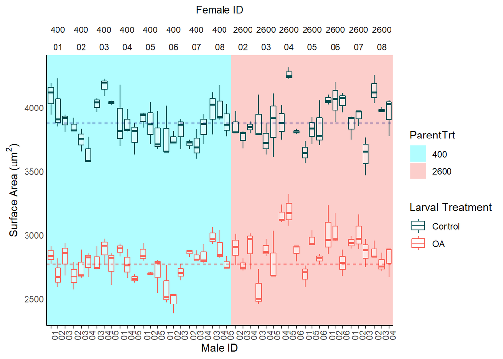

```r
ggplot(LarvByJarVarVizDat, aes(y=LarvaeAreaum2,x=as.factor(MaleIDNumber), color=JarTrt))+
  geom_boxplot(alpha=0.5, position="identity") +
  facet_grid(~ParentTrt*FemaleIDNumber, scale="free_x")+
  geom_rect(aes(xmin=-Inf, xmax=Inf, ymin=-Inf, ymax=Inf, fill = ParentTrt), colour=NA)+
  scale_fill_manual(values =c("#B1FDFF", "#FCCECB"))+
   geom_boxplot(alpha=0.5, position="identity") +
  labs(x = "Male ID", y= expression(paste("Surface Area (", mu, m^2,")")), title = "Female ID") +
  scale_color_manual(name = "Larval Treatment", labels = c("Control", "OA"), values = c("#004D4F", "#F7645A"))+
  geom_hline(aes(yintercept=ConConMeans$LarvaeAreaum2), color= "navyblue", lty=2)+
  geom_hline(aes(yintercept=ConExpMeans$LarvaeAreaum2), color= "red", lty=2)+
    theme_classic() +
  theme(axis.title.y.right = element_blank(),                # hide right axis title
        axis.text.y.right = element_blank(),                 # hide right axis labels
        axis.ticks.y = element_blank(),                      # hide left/right axis ticks
        axis.text.y = element_text(margin = margin(r = 0)),  # move left axis labels closer to axis
        panel.spacing = unit(0, "mm"),                    # remove spacing between facets
        strip.background = element_rect(colour="white", fill="white"), axis.text.x=element_text(angle=90),plot.title = element_text(size=10, hjust = 0.5), panel.border= element_blank())
```

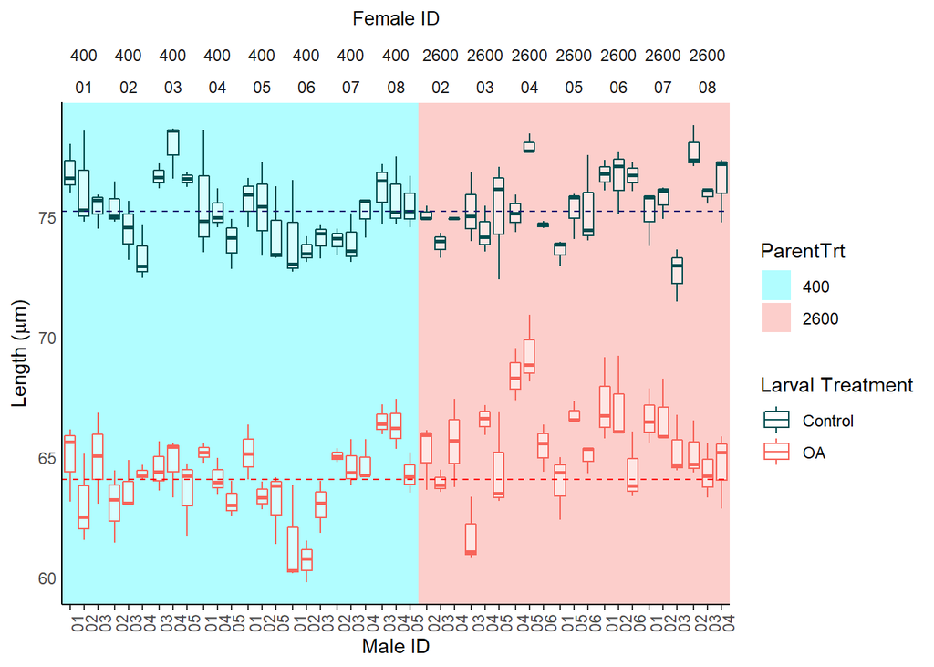

```r
ggplot(LarvByJarVarVizDat, aes(y=LarvaeDiamum ,x=MaleIDNumber, color=JarTrt))+
   geom_boxplot(alpha=0.5, position="identity") +
  facet_grid(~ParentTrt*FemaleIDNumber, scale="free_x")+
  geom_rect(aes(xmin=-Inf, xmax=Inf, ymin=-Inf, ymax=Inf, fill = ParentTrt), colour=NA)+
  scale_fill_manual(values =c("#B1FDFF", "#FCCECB"))+
   geom_boxplot(alpha=0.5, position="identity") +
  labs(x = "Male ID", y= expression(paste("Length (", mu, "m)")), title = "Female ID") +
    scale_color_manual(name = "Larval Treatment", labels = c("Control", "OA"), values = c("#004D4F", "#F7645A"))+

  geom_hline(yintercept=ConConMeans$LarvaeDiamum, color="midnightblue", lty=2)+
  geom_hline(yintercept=ConExpMeans$LarvaeDiamum, color="red", lty=2)+
    theme_classic() +
  theme(axis.title.y.right = element_blank(),                # hide right axis title
        axis.text.y.right = element_blank(),                 # hide right axis labels
        axis.ticks.y = element_blank(),                      # hide left/right axis ticks
        axis.text.y = element_text(margin = margin(r = 0)),  # move left axis labels closer to axis
        panel.spacing = unit(0, "mm"),                    # remove spacing between facets
        strip.background = element_rect(colour="white", fill="white"), axis.text.x=element_text(angle=90),plot.title = element_text(size=10, hjust = 0.5), panel.border= element_blank())
```

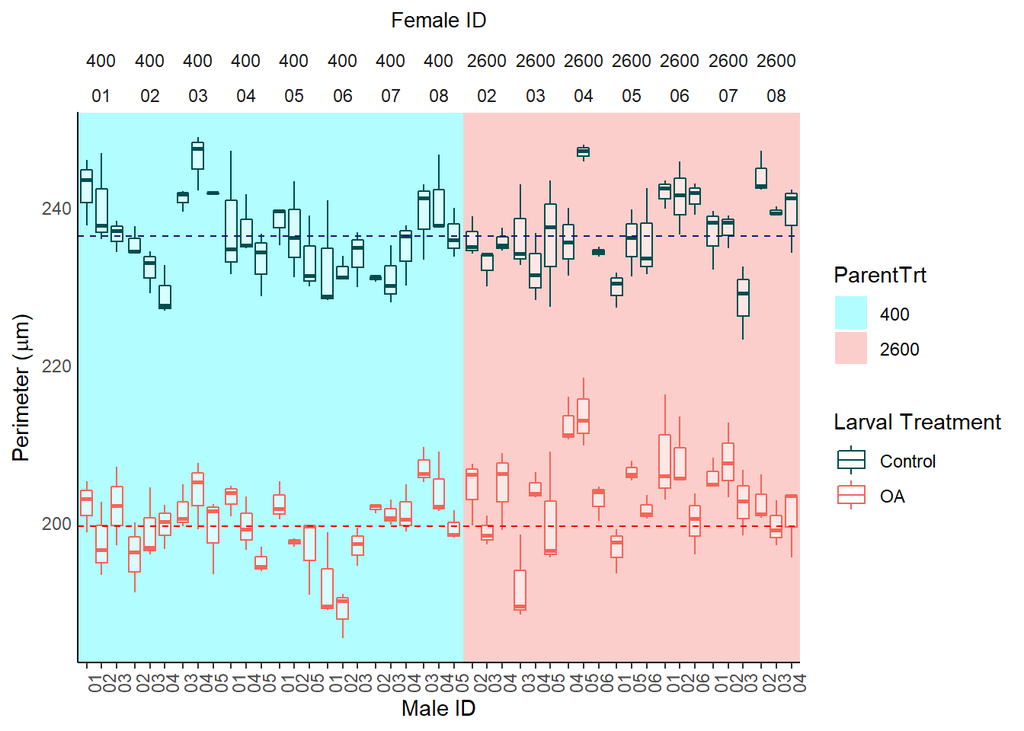

```r
ggplot(LarvByJarVarVizDat, aes(y=LarvaePerimeterum ,x=MaleIDNumber, color=JarTrt))+
    geom_boxplot(alpha=0.5, position="identity") +
  facet_grid(~ParentTrt*FemaleIDNumber, scale="free_x")+
  geom_rect(aes(xmin=-Inf, xmax=Inf, ymin=-Inf, ymax=Inf, fill = ParentTrt), colour=NA)+
  scale_fill_manual(values =c("#B1FDFF", "#FCCECB"))+
   geom_boxplot(alpha=0.5, position="identity") +
  labs(x = "Male ID", y= expression(paste("Perimeter (", mu, "m)")), title = "Female ID") +
      scale_color_manual(name = "Larval Treatment", labels = c("Control", "OA"), values = c("#004D4F", "#F7645A"))+

  geom_hline(yintercept=ConConMeans$LarvaePerimeterum, color="midnightblue", lty=2)+
  geom_hline(yintercept=ConExpMeans$LarvaePerimeterum, color="red", lty=2)+
    theme_classic() +
  theme(axis.title.y.right = element_blank(),                # hide right axis title
        axis.text.y.right = element_blank(),                 # hide right axis labels
        axis.ticks.y = element_blank(),                      # hide left/right axis ticks
        axis.text.y = element_text(margin = margin(r = 0)),  # move left axis labels closer to axis
        panel.spacing = unit(0, "mm"),                    # remove spacing between facets
        strip.background = element_rect(colour="white", fill="white"), axis.text.x=element_text(angle=90),plot.title = element_text(size=10, hjust = 0.5), panel.border= element_blank())
```

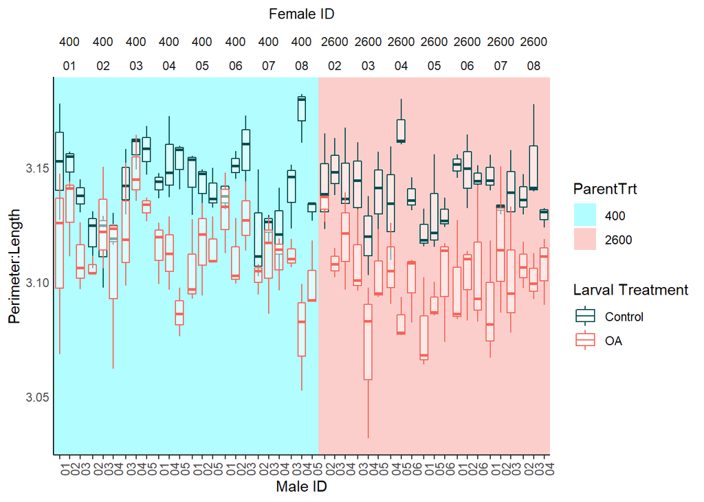

```r
ggplot(LarvByJarVarVizDat, aes(y=(LarvaePerimeterum/LarvaeDiamum),x=MaleIDNumber, color=JarTrt))+
  geom_boxplot(alpha=0.5, position="identity") +
  facet_grid(~ParentTrt*FemaleIDNumber, scale="free_x")+
  geom_rect(aes(xmin=-Inf, xmax=Inf, ymin=-Inf, ymax=Inf, fill = ParentTrt), colour=NA)+
  scale_fill_manual(values =c("#B1FDFF", "#FCCECB"))+
   geom_boxplot(alpha=0.5, position="identity") +
  labs(x = "Male ID", y= paste("Perimeter:Length"), title = "Female ID") +
    scale_color_manual(name = "Larval Treatment", labels = c("Control", "OA"), values = c("#004D4F", "#F7645A"))+
    theme_classic() +
  theme(axis.title.y.right = element_blank(),                # hide right axis title
        axis.text.y.right = element_blank(),                 # hide right axis labels
        axis.ticks.y = element_blank(),                      # hide left/right axis ticks
        axis.text.y = element_text(margin = margin(r = 0)),  # move left axis labels closer to axis
        panel.spacing = unit(0, "mm"),                    # remove spacing between facets
        strip.background = element_rect(colour="white", fill="white"), axis.text.x=element_text(angle=90),plot.title = element_text(size=10, hjust = 0.5), panel.border= element_blank())
```

# Visualize variance in a faceted way

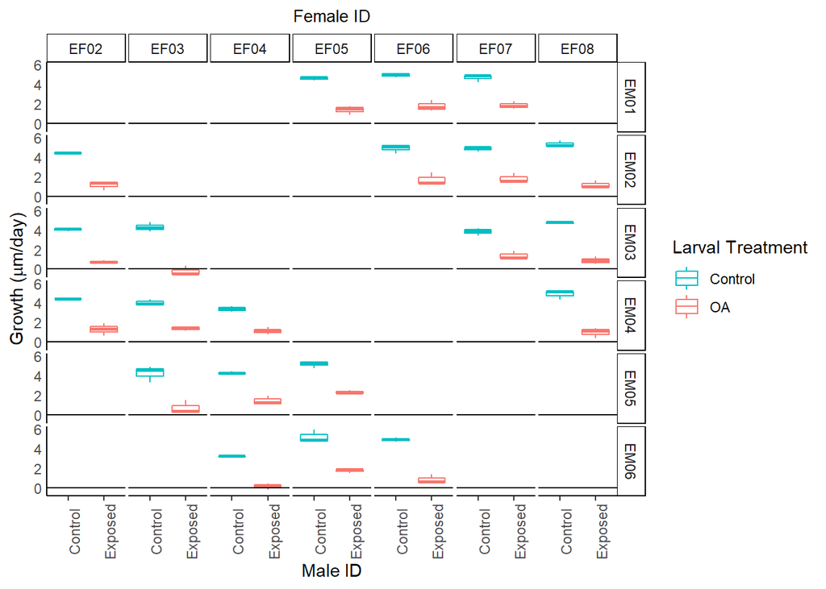

```r
#EF01_EM01 only has one cross, so a boxplot won't work. Remove from the data before trying to make the plots:
LarvByJarVarVizDat<- subset(LarvByJarDat, CrossID !="EF01_EM01_B1_QG")
Exposed.Parents<- subset(LarvByJarVarVizDat, ParentTrt=="2600")
Control.Parents<- subset(LarvByJarVarVizDat, ParentTrt=="400")
ggplot(Exposed.Parents, aes(y=MeanGPD,x=JarTrt, color=JarTrt))+
  geom_boxplot(alpha=0.5, position="identity") +
  facet_grid(MaleIDPlain~FemIDPlain, scale="free_x")+
  labs(x = "Male ID", y= expression(paste("Growth (", mu, "m/day)")), title = "Female ID") +
  scale_color_manual(name = "Larval Treatment", labels = c("Control", "OA"), values = c("#00BFC4", "#F8766D"))+
  geom_hline(yintercept=0)+
    theme_classic() +
  theme(axis.title.y.right = element_blank(),                # hide right axis title
        axis.text.y.right = element_blank(),                 # hide right axis labels
        axis.ticks.y = element_blank(),                      # hide left/right axis ticks
        axis.text.y = element_text(margin = margin(r = 0)),  # move left axis labels closer to axis
        panel.spacing = unit(0.7, "mm"),                    # remove spacing between facets
        strip.background = element_rect(size = 0.5), axis.text.x=element_text(angle=90),plot.title = element_text(size=10, hjust = 0.5))
```

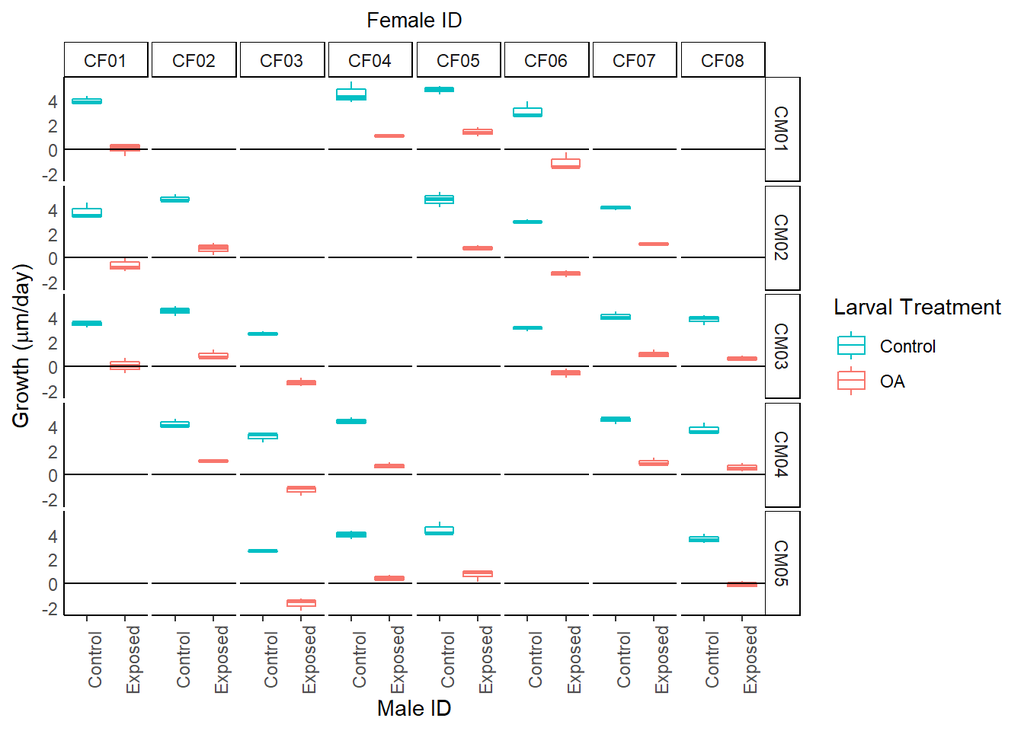

```r
ggplot(Control.Parents, aes(y=MeanGPD,x=JarTrt, color=JarTrt))+
  geom_boxplot(alpha=0.5, position="identity") +
  facet_grid(MaleIDPlain~FemIDPlain, scale="free_x")+
  labs(x = "Male ID", y= expression(paste("Growth (", mu, "m/day)")), title = "Female ID") +
  scale_color_manual(name = "Larval Treatment", labels = c("Control", "OA"), values = c("#00BFC4", "#F8766D"))+
  geom_hline(yintercept=0)+
    theme_classic() +
  theme(axis.title.y.right = element_blank(),                # hide right axis title
        axis.text.y.right = element_blank(),                 # hide right axis labels
        axis.ticks.y = element_blank(),                      # hide left/right axis ticks
        axis.text.y = element_text(margin = margin(r = 0)),  # move left axis labels closer to axis
        panel.spacing = unit(0.7, "mm"),                    # remove spacing between facets
        strip.background = element_rect(size = 0.5), axis.text.x=element_text(angle=90),plot.title = element_text(size=10, hjust = 0.5))
```

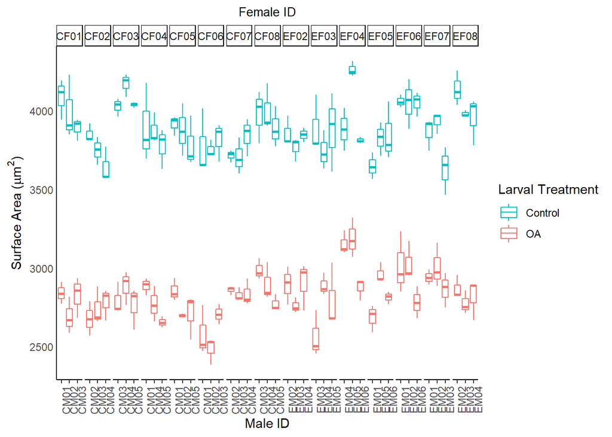

```r
#not fixed below
ggplot(LarvByJarVarVizDat, aes(y=LarvaeAreaum2,x=MaleIDPlain, color=JarTrt))+
  geom_boxplot(alpha=0.5, position="identity") +
  facet_grid(~FemIDPlain, scale="free_x")+
  labs(x = "Male ID", y= expression(paste("Surface Area (", mu, m^2,")")), title = "Female ID") +
  scale_color_manual(name = "Larval Treatment", labels = c("Control", "OA"), values = c("#00BFC4", "#F8766D"))+
    theme_classic() +
  theme(axis.title.y.right = element_blank(),                # hide right axis title
        axis.text.y.right = element_blank(),                 # hide right axis labels
        axis.ticks.y = element_blank(),                      # hide left/right axis ticks
        axis.text.y = element_text(margin = margin(r = 0)),  # move left axis labels closer to axis
        panel.spacing = unit(0.7, "mm"),                    # remove spacing between facets
        strip.background = element_rect(size = 0.5), axis.text.x=element_text(angle=90),plot.title = element_text(size=10, hjust = 0.5))
```

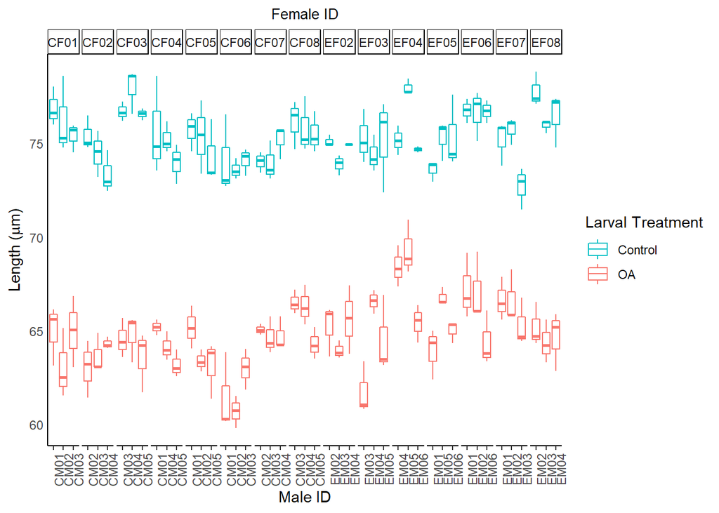

```r
ggplot(LarvByJarVarVizDat, aes(y=LarvaeDiamum ,x=MaleIDPlain, color=JarTrt))+
  geom_boxplot(alpha=0.5, position="identity") +
  facet_grid(~FemIDPlain, scale="free_x")+
  labs(x = "Male ID", y= expression(paste("Length (", mu, "m)")), title = "Female ID") +
  scale_color_manual(name = "Larval Treatment", labels = c("Control", "OA"), values = c("#00BFC4", "#F8766D"))+
    theme_classic() +
  theme(axis.title.y.right = element_blank(),                # hide right axis title
        axis.text.y.right = element_blank(),                 # hide right axis labels
        axis.ticks.y = element_blank(),                      # hide left/right axis ticks
        axis.text.y = element_text(margin = margin(r = 0)),  # move left axis labels closer to axis
        panel.spacing = unit(0.7, "mm"),                    # remove spacing between facets
        strip.background = element_rect(size = 0.5), axis.text.x=element_text(angle=90),plot.title = element_text(size=10, hjust = 0.5))
```

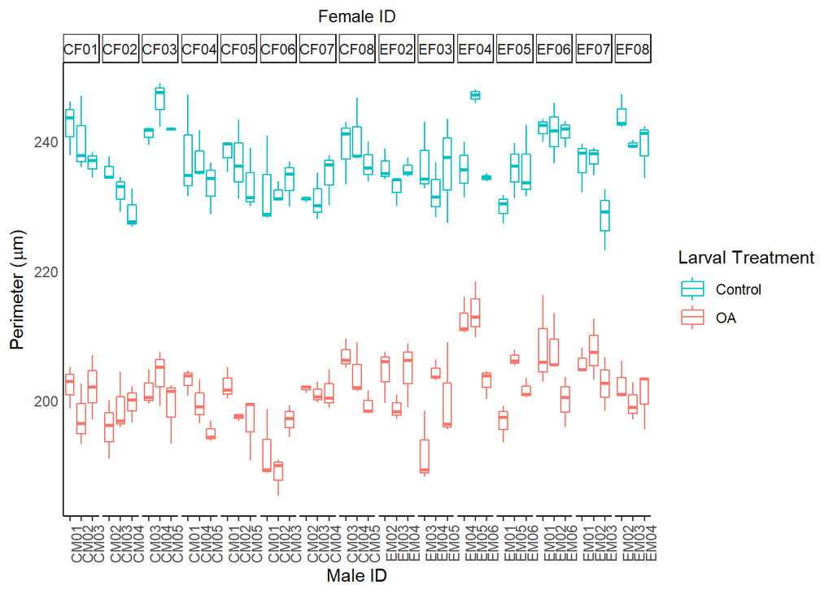

```r
ggplot(LarvByJarVarVizDat, aes(y=LarvaePerimeterum ,x=MaleIDPlain, color=JarTrt))+
  geom_boxplot(alpha=0.5, position="identity") +
  facet_grid(~FemIDPlain, scale="free_x")+
  labs(x = "Male ID", y= expression(paste("Perimeter (", mu, "m)")), title = "Female ID") +
  scale_color_manual(name = "Larval Treatment", labels = c("Control", "OA"), values = c("#00BFC4", "#F8766D"))+
    theme_classic() +
  theme(axis.title.y.right = element_blank(),                # hide right axis title
        axis.text.y.right = element_blank(),                 # hide right axis labels
        axis.ticks.y = element_blank(),                      # hide left/right axis ticks
        axis.text.y = element_text(margin = margin(r = 0)),  # move left axis labels closer to axis
        panel.spacing = unit(0.7, "mm"),                    # remove spacing between facets
        strip.background = element_rect(size = 0.5), axis.text.x=element_text(angle=90),plot.title = element_text(size=10, hjust = 0.5))
```

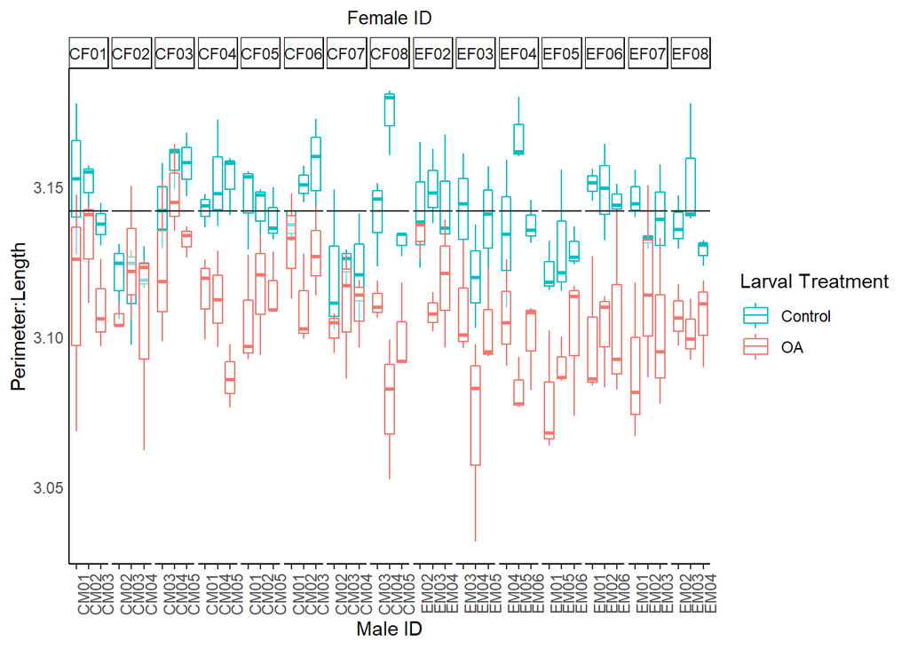

```r
ggplot(LarvByJarVarVizDat, aes(y=(LarvaePerimeterum/LarvaeDiamum),x=MaleIDPlain, color=JarTrt))+
  geom_boxplot(alpha=0.5, position="identity") +
  facet_grid(~FemIDPlain, scale="free_x")+
  labs(x = "Male ID", y= paste("Perimeter:Length"), title = "Female ID") +
  scale_color_manual(name = "Larval Treatment", labels = c("Control", "OA"), values = c("#00BFC4", "#F8766D"))+
  geom_hline(yintercept= 3.142)+
    theme_classic() +
  theme(axis.title.y.right = element_blank(),                # hide right axis title
        axis.text.y.right = element_blank(),                 # hide right axis labels
        axis.ticks.y = element_blank(),                      # hide left/right axis ticks
        axis.text.y = element_text(margin = margin(r = 0)),  # move left axis labels closer to axis
        panel.spacing = unit(0.7, "mm"),                    # remove spacing between facets
        strip.background = element_rect(size = 0.5), axis.text.x=element_text(angle=90),plot.title = element_text(size=10, hjust = 0.5))
```

Visualize larval survival

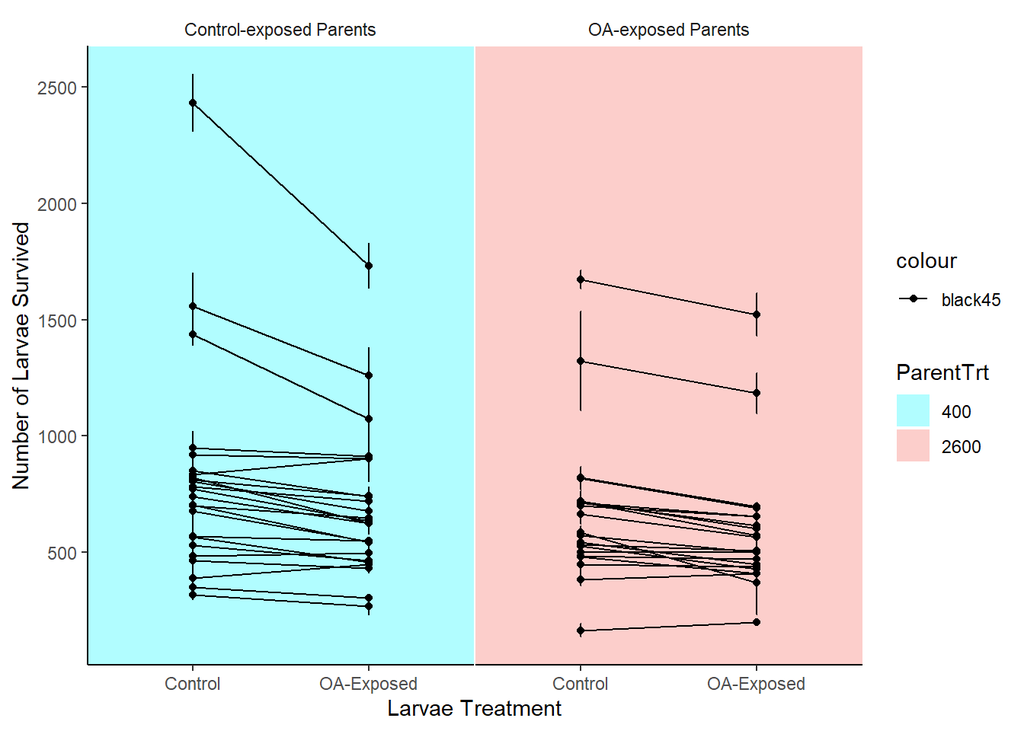

```r
SurvDat$ParentTrt<- factor(SurvDat$ParentTrt, levels=c("400", "2600"))
MeanSurvDat<- ddply(SurvWideDat, .(ParentTrt), numcolwise(mean, na.rm=T))
MeanSurvDat$ParentTrt<- factor(MeanSurvDat$ParentTrt, levels= c("400", "2600"))
SESurvDat<- ddply(SurvWideDat, .(ParentTrt), numcolwise(se, na.rm=T))
SESurvDat$ParentTrt<- factor(SESurvDat$ParentTrt, levels= c("400", "2600"))
#make reaction norms for survival color will be parent treatment. X will be jar treatment. Each cross will be its own line
ParTreat<- c("400"="Control-exposed Parents", "2600"="OA-exposed Parents")
LarvTreat<- c("Control"= "Control", "Exposed" = "OA-Exposed")
ggplot(SurvDat,aes(x=JarTrt, y=LarvaeSurvived, color = "black45", group= CrossID)) +
  geom_rect(aes(xmin=-Inf, xmax=Inf, ymin=-Inf, ymax=Inf, fill = ParentTrt), colour=NA)+
  scale_fill_manual(values =c("#B1FDFF", "#FCCECB"))+
    geom_point(aes(color="black45"))+
  geom_line(aes(color="black45", group=CrossID))+
  scale_x_discrete(labels=LarvTreat)+
  geom_errorbar(aes(ymin= LarvaeSurvived-SELarvaeSurvived, ymax=LarvaeSurvived+SELarvaeSurvived),width=0.05, position=position_dodge(0))+
    labs(x = "Larvae Treatment", y = "Number of Larvae Survived") +
  scale_color_manual(values="black")+

  facet_grid(.~ParentTrt, labeller =labeller(ParentTrt = ParTreat))+
  theme_classic() +
  theme(panel.spacing = unit(0.2, "mm"),                    # remove spacing between facets
        strip.background = element_rect(colour="white", fill="white"), panel.border= element_blank())
```

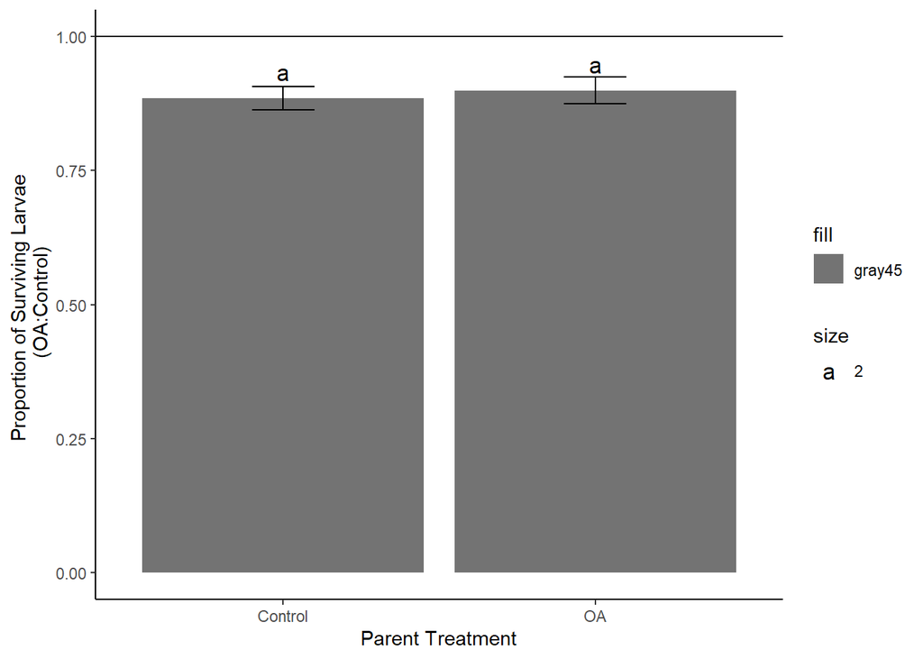

```r
#make bar graph of survival
ggplot(data = MeanSurvDat, aes(x = ParentTrt, y = RatSurv, fill="gray45")) +
  geom_bar(stat="identity", position="dodge")+
  ylim(c(0,1))+
  geom_hline(yintercept=1)+
  geom_errorbar(aes(ymin= RatSurv-SESurvDat$RatSurv, ymax=RatSurv+SESurvDat$RatSurv),width=0.2, position=position_dodge(.9))+
  labs(x = "Parent Treatment", y = "Proportion of Surviving Larvae \n (OA:Control)") +
  scale_x_discrete(breaks=c("400","2600"),
        labels=c("Control", "OA"))+
  scale_fill_manual(values = "gray45") +
   geom_text(aes(label=c("a", "a"),
            position = 3,
            size=2), vjust = -1)+
  theme_classic()
```

## Visualize variance in survival by family

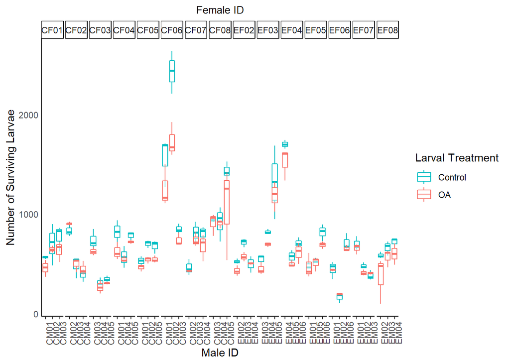

```r
#get percent differences in survival.
SurvWideDat$OACont_Perc<- (SurvWideDat$MeanLarvSurvivedExp-SurvWideDat$MeanLarvSurvivedCon)/SurvWideDat$MeanLarvSurvivedCon

ggplot(LarvByJarVarVizDat, aes(y=LarvaeSurvived,x=MaleIDPlain, color=JarTrt))+
  geom_boxplot(alpha=0.5, position="identity") +
  facet_grid(~FemIDPlain, scale="free_x")+
  labs(x = "Male ID", y= paste("Number of Surviving Larvae"), title = "Female ID") +
  scale_color_manual(name = "Larval Treatment", labels = c("Control", "OA"), values = c("#00BFC4", "#F8766D"))+
    theme_classic() +
  theme(axis.title.y.right = element_blank(),                # hide right axis title
        axis.text.y.right = element_blank(),                 # hide right axis labels
        axis.ticks.y = element_blank(),                      # hide left/right axis ticks
        axis.text.y = element_text(margin = margin(r = 0)),  # move left axis labels closer to axis
        panel.spacing = unit(0.7, "mm"),                    # remove spacing between facets
        strip.background = element_rect(size = 0.5), axis.text.x=element_text(angle=90),plot.title = element_text(size=10, hjust = 0.5))
```

# Try to look at trade offs between growth and survival

I am very confused by the following. I don’t know how to choose an approach. I thought that looking within each treatment combo made the most sense because of the interaction. So I do that in the next chunk. Depending on how you do it, you get different directions of the slope.

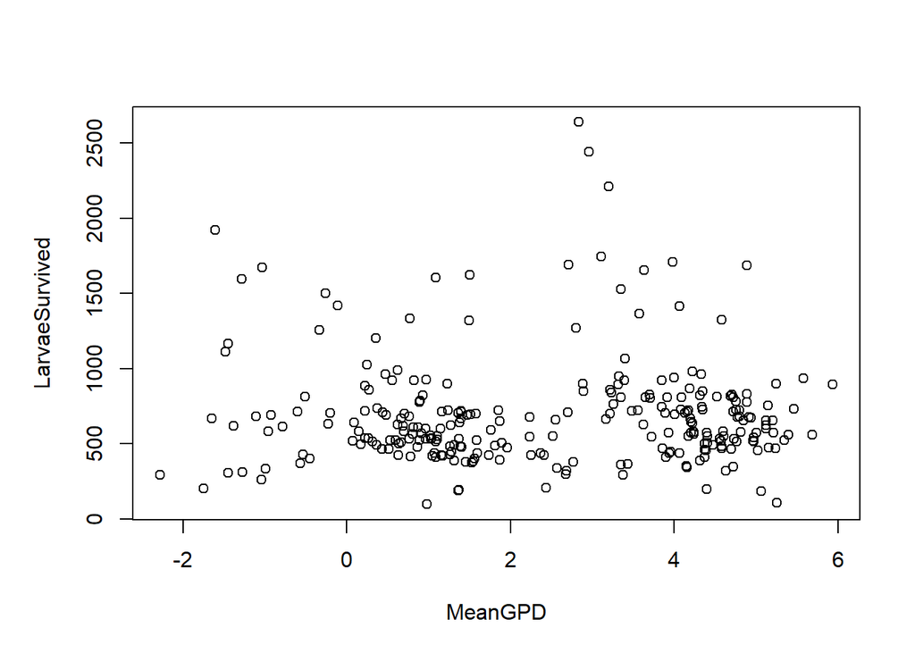

```r
par(mfcol=c(1,1), mar= c(5.1, 5.1, 4.1, 2.1))
plot(LarvaeSurvived~MeanGPD, data=LarvByJarDat)
```

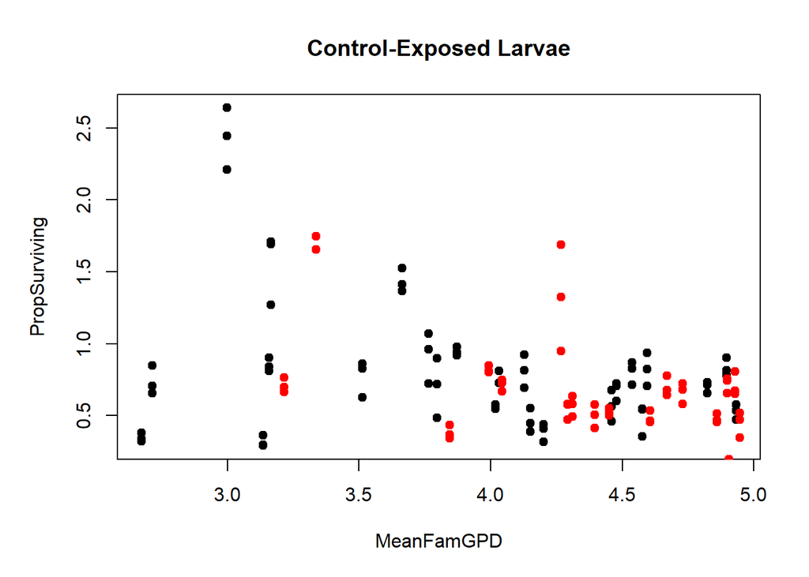

```r
#get proportion surviving for each jar
LarvByJarDat$PropSurviving<- LarvByJarDat$LarvaeSurvived/1000

#get mean GPD in control conditions for each family
LarvByJarDat$MeanFamGPD<- SurvWideDat$MeanGPDCon[match(LarvByJarDat$CrossID, SurvWideDat$CrossID)]
LarvByJarDat$RatSurv<- SurvWideDat$RatSurv[match(LarvByJarDat$CrossID, SurvWideDat$CrossID)] # add the ratio of survival for each family to the larvbyjardat data frame
LarvByJarDat$RatGPD<- SurvWideDat$RatGPD[match(LarvByJarDat$CrossID, SurvWideDat$CrossID)] #add the ratio of growth pear day for each family to the larvbyjardat dataframe
LarvByJarDatConParentsConLarvae<- subset(LarvByJarDat, ParentTrt=="400" & JarTrt=="Control")
LarvByJarDatExpParentsConLarvae<- subset(LarvByJarDat, ParentTrt=="2600" & JarTrt=="Control")
LarvByJarDatConLarvae<- subset(LarvByJarDat, JarTrt=="Control")
LarvByJarDatExpLarvae<- subset(LarvByJarDat, JarTrt=="Exposed")
LarvByJarDatConParents<- subset(LarvByJarDat, ParentTrt=="400")
LarvByJarDatExpParents<- subset(LarvByJarDat, ParentTrt=="2600")
#now plot that the proportion of surviving larvae by the mean growth per day in control jars for that family
plot(PropSurviving~MeanFamGPD, data=LarvByJarDatConParentsConLarvae, col="black", pch=19, main="Control-Exposed Larvae")
points(PropSurviving~MeanFamGPD, data=LarvByJarDatExpParentsConLarvae, col="red", pch=19)
```

```r
#lmer for control larvae
conlarv1<- lmer(PropSurviving~MeanFamGPD*ParentTrt + (1|FemaleID) + (1|MaleID), data=LarvByJarDatConLarvae)
conlarv1step<- step(conlarv1)
print(conlarv1step)
```

```
## Backward reduced random-effect table:
##
##                Eliminated npar  logLik     AIC    LRT Df Pr(>Chisq)
## <none>                       7 -39.775  93.551
## (1 | FemaleID)          0    6 -61.365 134.731 43.180  1  4.993e-11 ***
## (1 | MaleID)            0    6 -43.192  98.384  6.833  1   0.008947 **
## ---
## Signif. codes:  0 '***' 0.001 '**' 0.01 '*' 0.05 '.' 0.1 ' ' 1
##
## Backward reduced fixed-effect table:
## Degrees of freedom method: Satterthwaite
##
##                      Eliminated  Sum Sq Mean Sq NumDF  DenDF F value  Pr(>F)
## MeanFamGPD:ParentTrt          1 0.01369 0.01369     1 49.242  0.1853 0.66877
## ParentTrt                     2 0.00625 0.00625     1 18.036  0.0848 0.77422
## MeanFamGPD                    0 0.43413 0.43413     1 45.604  5.8885 0.01925 *
## ---
## Signif. codes:  0 '***' 0.001 '**' 0.01 '*' 0.05 '.' 0.1 ' ' 1
##
## Model found:
## PropSurviving ~ MeanFamGPD + (1 | FemaleID) + (1 | MaleID)
```

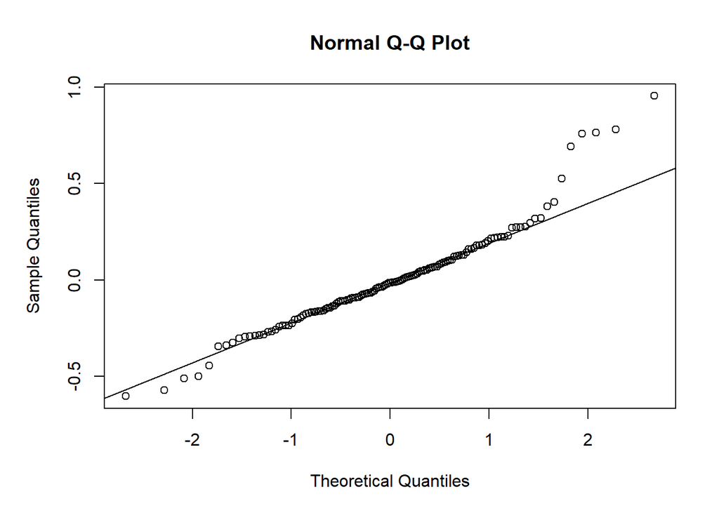

```r
conlarvfin<-lmer( PropSurviving~MeanFamGPD + (1|FemaleID) + (1|MaleID), data=LarvByJarDatConLarvae)
#check assumptions
qqnorm(resid(conlarvfin))
qqline(resid(conlarvfin))
```

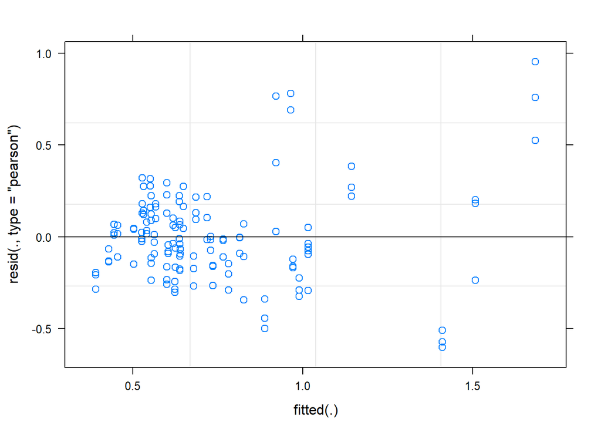

```r
plot(conlarvfin)
```

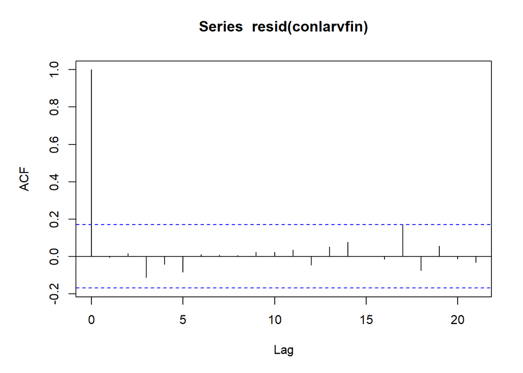

```r
acf(resid(conlarvfin))
```

```r
#looks like meets all assumptions
summary(conlarvfin)
```

```
## Linear mixed model fit by REML. t-tests use Satterthwaite's method [
## lmerModLmerTest]
## Formula: PropSurviving ~ MeanFamGPD + (1 | FemaleID) + (1 | MaleID)
##    Data: LarvByJarDatConLarvae
##
## REML criterion at convergence: 76.2
##
## Scaled residuals:
##     Min      1Q  Median      3Q     Max
## -2.2169 -0.5708 -0.0532  0.4546  3.5156
##
## Random effects:
##  Groups   Name        Variance Std.Dev.
##  FemaleID (Intercept) 0.05745  0.2397
##  MaleID   (Intercept) 0.01311  0.1145
##  Residual             0.07372  0.2715
## Number of obs: 134, groups:  FemaleID, 15; MaleID, 11
##
## Fixed effects:
##             Estimate Std. Error       df t value Pr(>|t|)
## (Intercept)  1.53474    0.33564 43.42175   4.573 3.98e-05 ***
## MeanFamGPD  -0.18863    0.07773 45.60432  -2.427   0.0193 *
## ---
## Signif. codes:  0 '***' 0.001 '**' 0.01 '*' 0.05 '.' 0.1 ' ' 1
##
## Correlation of Fixed Effects:
##            (Intr)
## MeanFamGPD -0.975
```

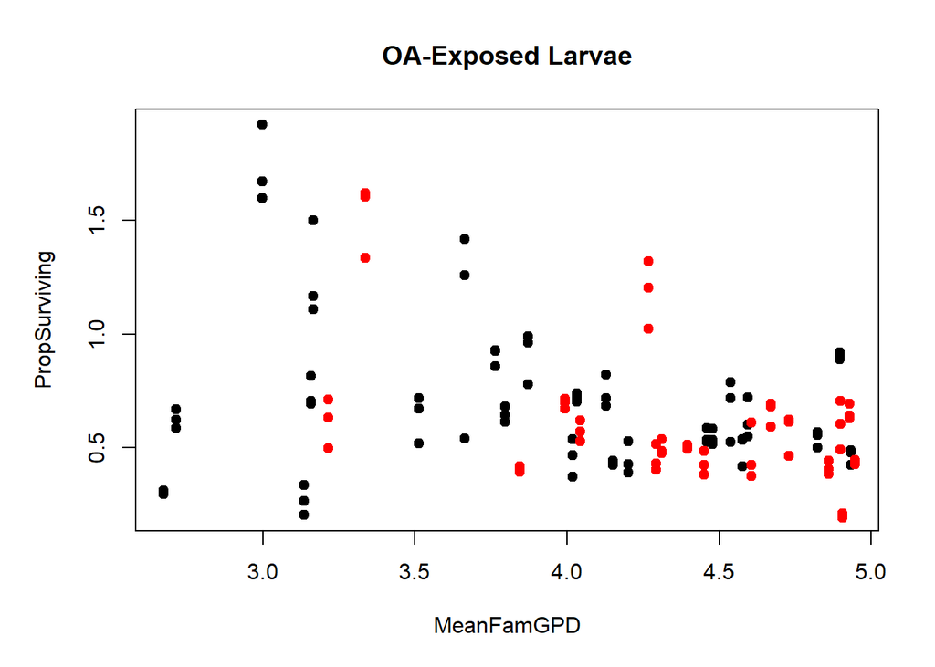

```r
LarvByJarDatConParentsExpLarvae<- subset(LarvByJarDat, ParentTrt=="400" & JarTrt=="Exposed")
LarvByJarDatExpParentsExpLarvae<- subset(LarvByJarDat, ParentTrt=="2600" & JarTrt=="Exposed")
par(mfcol=c(1,1))
plot(PropSurviving~MeanFamGPD, data=LarvByJarDatConParentsExpLarvae, col="black", pch=19, main="OA-Exposed Larvae")
points(PropSurviving~MeanFamGPD, data=LarvByJarDatExpParentsExpLarvae, col="red", pch=19)
```

```r
#lmer for exposed larvae
explarv1<- lmer(PropSurviving~MeanFamGPD*ParentTrt + (1|FemaleID) + (1|MaleID), data=LarvByJarDatExpLarvae)
explarv1step<- step(explarv1)
print(explarv1step)
```

```
## Backward reduced random-effect table:
##
##                Eliminated npar  logLik    AIC    LRT Df Pr(>Chisq)
## <none>                       7 -13.270 40.540
## (1 | FemaleID)          0    6 -31.379 74.759 36.219  1  1.764e-09 ***
## (1 | MaleID)            0    6 -16.873 45.747  7.207  1   0.007263 **
## ---
## Signif. codes:  0 '***' 0.001 '**' 0.01 '*' 0.05 '.' 0.1 ' ' 1
##
## Backward reduced fixed-effect table:
## Degrees of freedom method: Satterthwaite
##
##                      Eliminated  Sum Sq Mean Sq NumDF  DenDF F value  Pr(>F)
## MeanFamGPD:ParentTrt          1 0.01265 0.01265     1 44.052  0.2542 0.61662
## ParentTrt                     2 0.00036 0.00036     1 18.554  0.0073 0.93263
## MeanFamGPD                    0 0.34207 0.34207     1 41.484  6.8971 0.01204 *
## ---
## Signif. codes:  0 '***' 0.001 '**' 0.01 '*' 0.05 '.' 0.1 ' ' 1
##
## Model found:
## PropSurviving ~ MeanFamGPD + (1 | FemaleID) + (1 | MaleID)
```

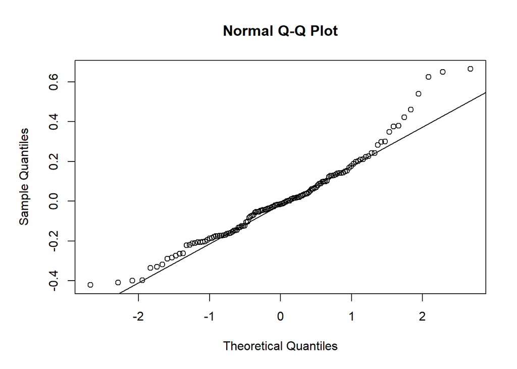

```r
explarvfin<-lmer( PropSurviving~MeanFamGPD + (1|FemaleID) + (1|MaleID), data=LarvByJarDatExpLarvae)
#check assumptions
qqnorm(resid(explarvfin))
qqline(resid(explarvfin))
```

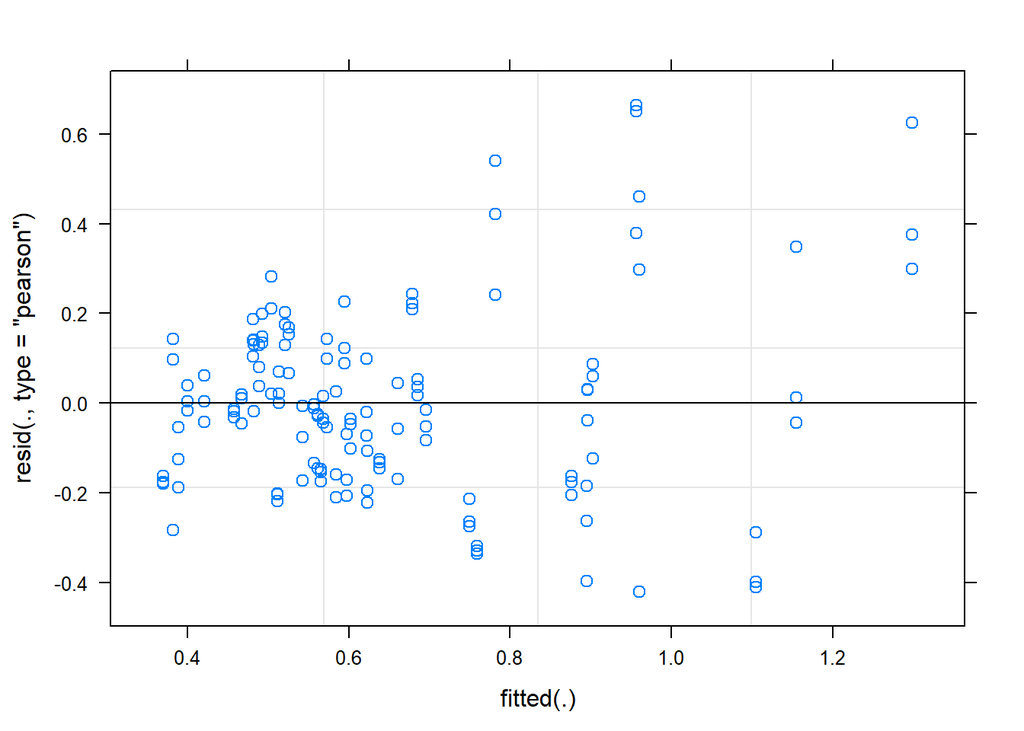

```r
plot(explarvfin)
```

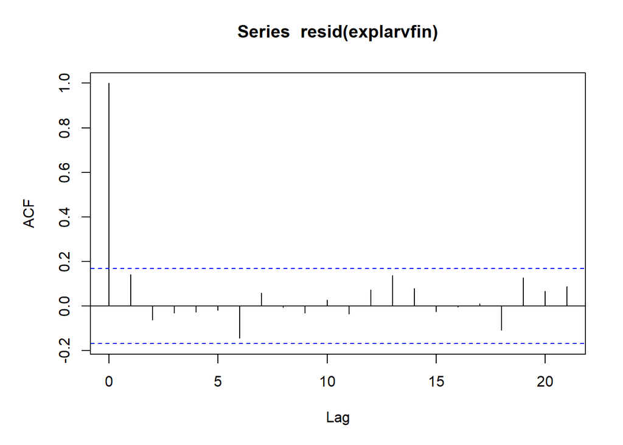

```r
acf(resid(explarvfin))
```

```r
#looks like meets all assumptions
summary(explarvfin)
```

```
## Linear mixed model fit by REML. t-tests use Satterthwaite's method [
## lmerModLmerTest]
## Formula: PropSurviving ~ MeanFamGPD + (1 | FemaleID) + (1 | MaleID)
##    Data: LarvByJarDatExpLarvae
##
## REML criterion at convergence: 22.2
##
## Scaled residuals:
##      Min       1Q   Median       3Q      Max
## -1.89365 -0.68038 -0.06722  0.50664  2.98477
##
## Random effects:
##  Groups   Name        Variance Std.Dev.
##  FemaleID (Intercept) 0.031939 0.17872
##  MaleID   (Intercept) 0.009571 0.09783
##  Residual             0.049597 0.22270
## Number of obs: 135, groups:  FemaleID, 15; MaleID, 11
##
## Fixed effects:
##             Estimate Std. Error       df t value Pr(>|t|)
## (Intercept)  1.32245    0.26402 40.01322   5.009 1.15e-05 ***
## MeanFamGPD  -0.16066    0.06117 41.48435  -2.626    0.012 *
## ---
## Signif. codes:  0 '***' 0.001 '**' 0.01 '*' 0.05 '.' 0.1 ' ' 1
##
## Correlation of Fixed Effects:
##            (Intr)
## MeanFamGPD -0.975
```

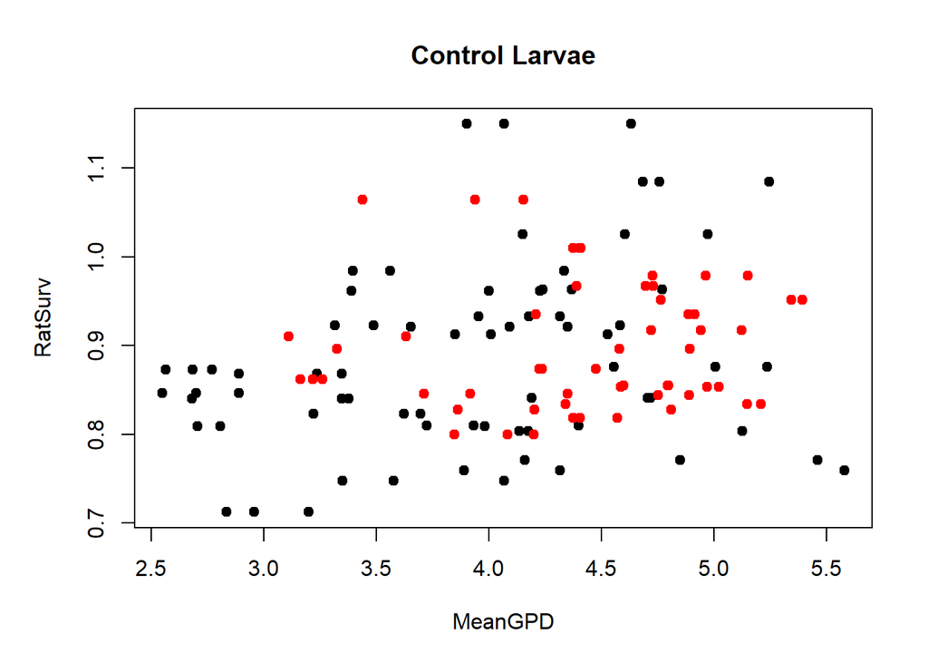

```r
#looks like a negative slope, but I am skeptical of this approach because of how dependent the starting number of larvae was on family

#analysis of surviving larvae with the ratio of survival in OA to control
plot(RatSurv~MeanGPD, data=LarvByJarDatConParentsConLarvae, pch=19, col="black", main= "Control Larvae")
points(RatSurv~MeanGPD, data=LarvByJarDatExpParentsConLarvae, pch=19, col="red")
```

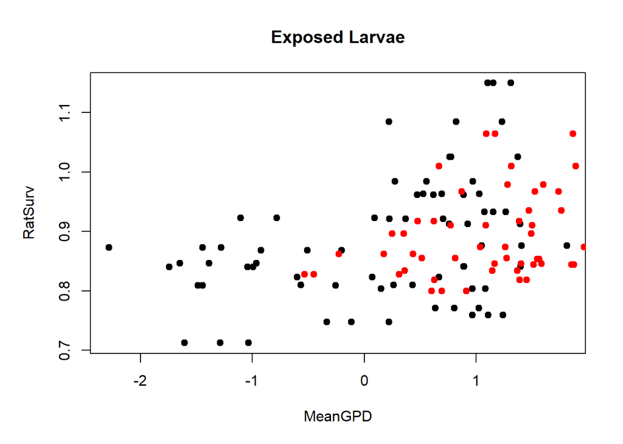

```r
plot(RatSurv~MeanGPD, data=LarvByJarDatConParentsExpLarvae, pch=19, col="black", main= "Exposed Larvae")
points(RatSurv~MeanGPD, data=LarvByJarDatExpParentsExpLarvae, pch=19, col="red")
```

```r
ratmod1<- lmer(RatSurv~MeanGPD*ParentTrt + (1|FemaleID)+ (1|MaleID), data=LarvByJarDatConLarvae)
ratmodstep<- step(ratmod1)
print(ratmodstep)
```

```
## Backward reduced random-effect table:
##
##                Eliminated npar  logLik     AIC    LRT Df Pr(>Chisq)
## <none>                       7 132.246 -250.49
## (1 | FemaleID)          0    6  99.463 -186.93 65.566  1  5.621e-16 ***
## (1 | MaleID)            0    6 126.894 -241.79 10.704  1   0.001069 **
## ---
## Signif. codes:  0 '***' 0.001 '**' 0.01 '*' 0.05 '.' 0.1 ' ' 1
##
## Backward reduced fixed-effect table:
## Degrees of freedom method: Satterthwaite
##
##                   Eliminated    Sum Sq   Mean Sq NumDF   DenDF F value Pr(>F)
## MeanGPD:ParentTrt          1 0.0095907 0.0095907     1 128.134  2.0705 0.1526
## ParentTrt                  2 0.0010085 0.0010085     1  15.729  0.2169 0.6478
## MeanGPD                    3 0.0098717 0.0098717     1 130.022  2.1187 0.1479
##
## Model found:
## RatSurv ~ (1 | FemaleID) + (1 | MaleID)
```

```r
ratmod2<- lmer(RatSurv~MeanGPD*ParentTrt + (1|FemaleID)+ (1|MaleID), data=LarvByJarDatExpLarvae)
ratmod2step<- step(ratmod2)
print(ratmod2step)
```

```
## Backward reduced random-effect table:
##
##                Eliminated npar logLik     AIC    LRT Df Pr(>Chisq)
## <none>                       7 132.47 -250.95
## (1 | FemaleID)          0    6 105.41 -198.82 54.130  1  1.877e-13 ***
## (1 | MaleID)            0    6 128.10 -244.19  8.756  1   0.003086 **
## ---
## Signif. codes:  0 '***' 0.001 '**' 0.01 '*' 0.05 '.' 0.1 ' ' 1
##
## Backward reduced fixed-effect table:
## Degrees of freedom method: Satterthwaite
##
##                   Eliminated    Sum Sq   Mean Sq NumDF   DenDF F value Pr(>F)
## MeanGPD:ParentTrt          1 0.0031561 0.0031561     1 118.143  0.6547 0.4200
## ParentTrt                  2 0.0000118 0.0000118     1  15.009  0.0024 0.9613
## MeanGPD                    3 0.0091572 0.0091572     1 105.189  1.8815 0.1731
##
## Model found:
## RatSurv ~ (1 | FemaleID) + (1 | MaleID)
```

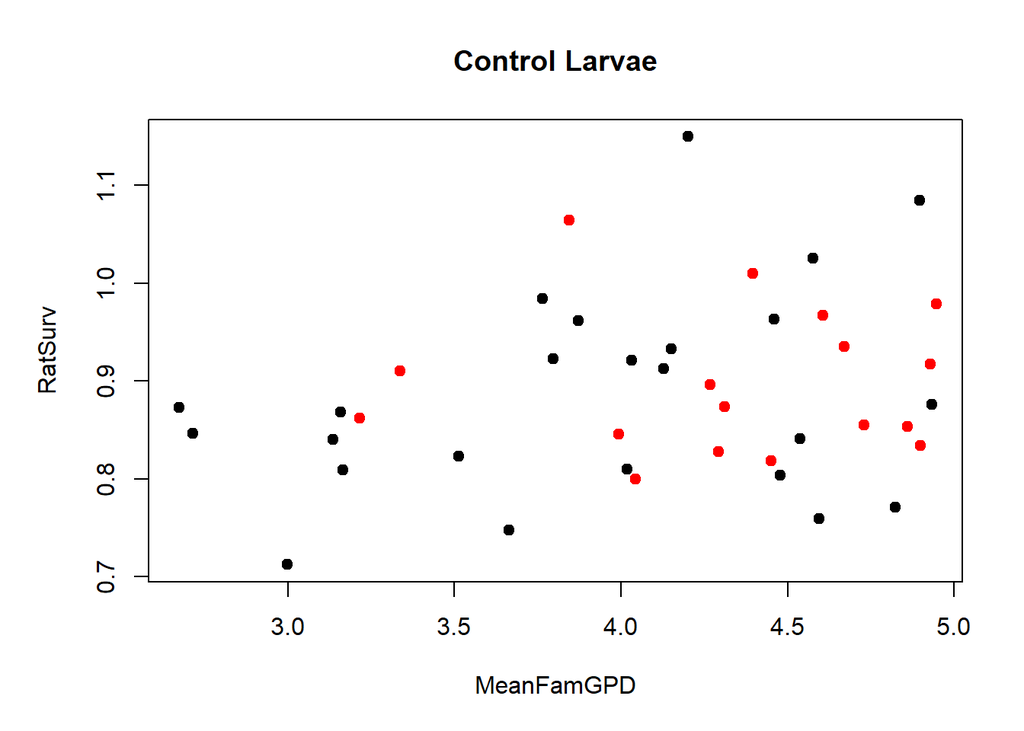

```r
#both control and exposed larvae select just random effects.

#or did she mean to plot by the mean GPD for families
plot(RatSurv~MeanFamGPD, data=LarvByJarDatConParentsConLarvae, pch=19, col="black", main= "Control Larvae")
points(RatSurv~MeanFamGPD, data=LarvByJarDatExpParentsConLarvae, pch=19, col="red")
```

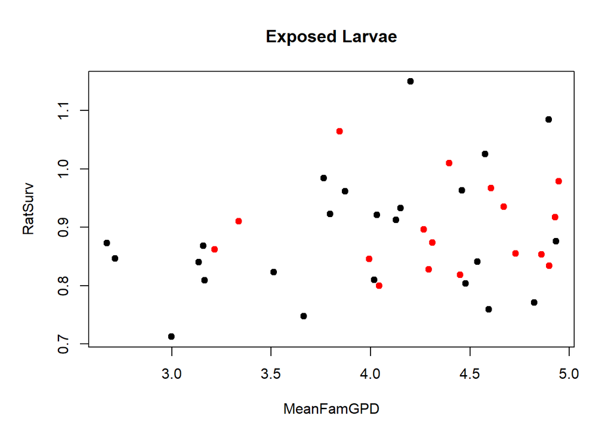

```r
plot(RatSurv~MeanFamGPD, data=LarvByJarDatConParentsExpLarvae, pch=19, col="black", main= "Exposed Larvae")
points(RatSurv~MeanFamGPD, data=LarvByJarDatExpParentsExpLarvae, pch=19, col="red")
```

```r
ratmod1a<- lmer(RatSurv~MeanFamGPD*ParentTrt + (1|FemaleID)+ (1|MaleID), data=LarvByJarDatConLarvae)
ratmodstepa<- step(ratmod1a)
print(ratmodstepa)
```

```
## Backward reduced random-effect table:
##
##                Eliminated npar logLik     AIC    LRT Df Pr(>Chisq)
## <none>                       7 136.53 -259.07
## (1 | FemaleID)          0    6 100.73 -189.46 71.608  1  < 2.2e-16 ***
## (1 | MaleID)            0    6 129.73 -247.46 13.612  1  0.0002247 ***
## ---
## Signif. codes:  0 '***' 0.001 '**' 0.01 '*' 0.05 '.' 0.1 ' ' 1
##
## Backward reduced fixed-effect table:
## Degrees of freedom method: Satterthwaite
##
##                      Eliminated   Sum Sq  Mean Sq NumDF  DenDF F value   Pr(>F)
## MeanFamGPD:ParentTrt          1 0.011780 0.011780     1 84.406  2.8012 0.097893
## ParentTrt                     2 0.003183 0.003183     1 13.774  0.7594 0.398455
## MeanFamGPD                    0 0.038290 0.038290     1 94.194  9.0743 0.003329
##
## MeanFamGPD:ParentTrt .
## ParentTrt
## MeanFamGPD           **
## ---
## Signif. codes:  0 '***' 0.001 '**' 0.01 '*' 0.05 '.' 0.1 ' ' 1
##
## Model found:
## RatSurv ~ MeanFamGPD + (1 | FemaleID) + (1 | MaleID)
```

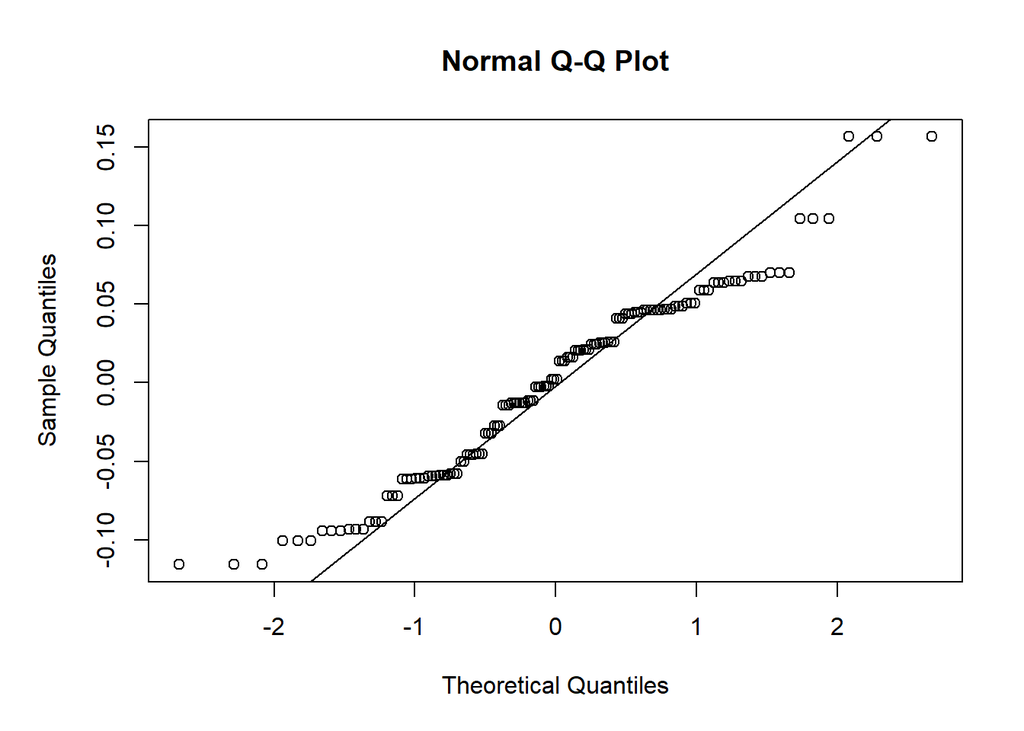

```r
ratmodfina<- lmer(RatSurv~MeanFamGPD+ (1|FemaleID)+ (1|MaleID), data=LarvByJarDatConLarvae)
qqnorm(resid(ratmodfina))
qqline(resid(ratmodfina))
```

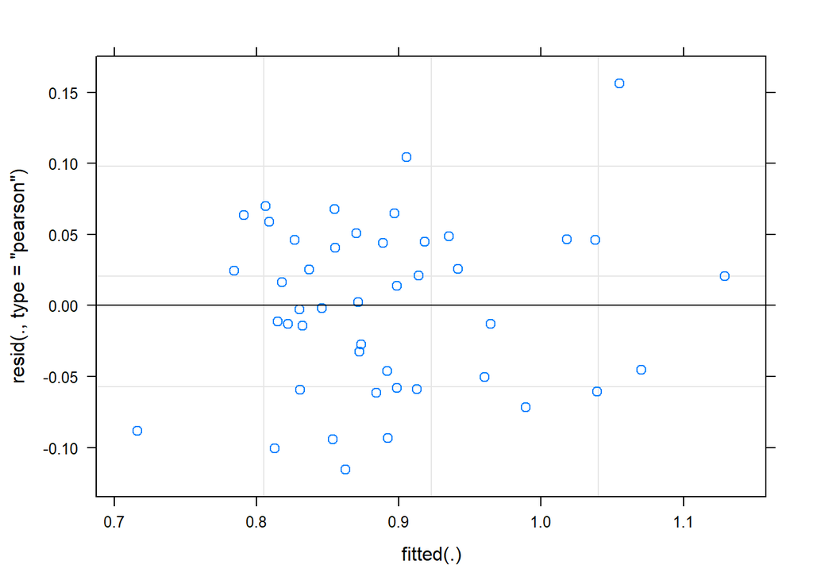

```r
plot(ratmodfina)
```

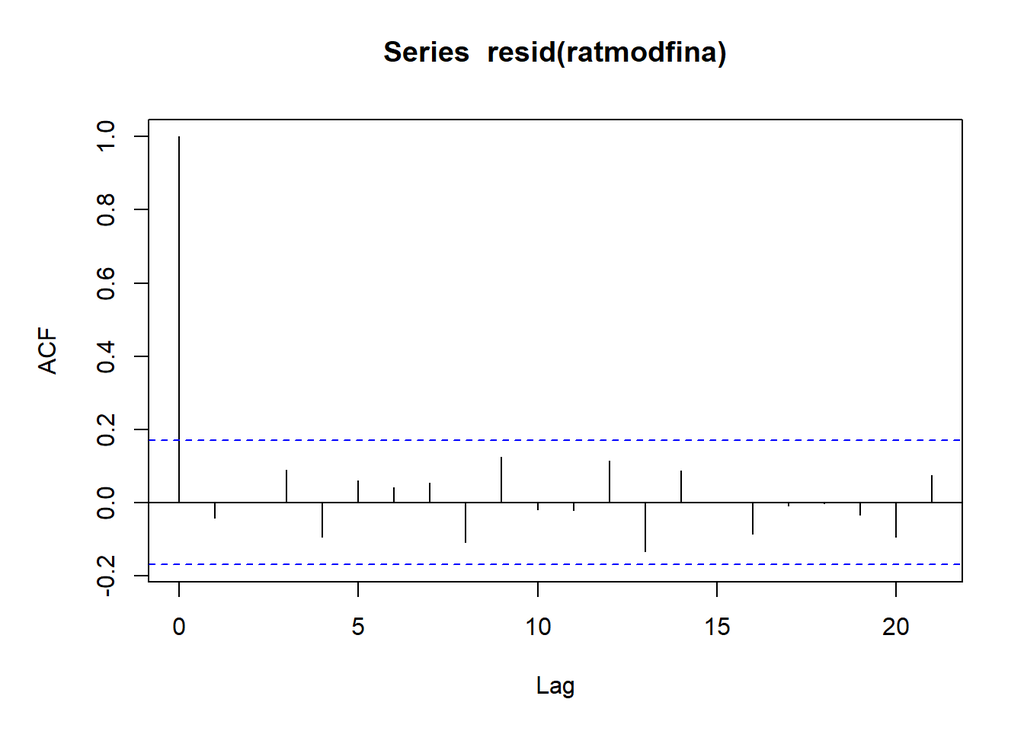

```r
acf(resid(ratmodfina))
```

```r
summary(ratmodfina)
```

```
## Linear mixed model fit by REML. t-tests use Satterthwaite's method [
## lmerModLmerTest]
## Formula: RatSurv ~ MeanFamGPD + (1 | FemaleID) + (1 | MaleID)
##    Data: LarvByJarDatConLarvae
##
## REML criterion at convergence: -277.2
##
## Scaled residuals:
##      Min       1Q   Median       3Q      Max
## -1.77956 -0.77326  0.03636  0.70794  2.40688
##
## Random effects:
##  Groups   Name        Variance Std.Dev.
##  FemaleID (Intercept) 0.01337  0.11563
##  MaleID   (Intercept) 0.00208  0.04561
##  Residual             0.00422  0.06496
## Number of obs: 134, groups:  FemaleID, 15; MaleID, 11
##
## Fixed effects:
##             Estimate Std. Error       df t value Pr(>|t|)
## (Intercept)  1.20354    0.10970 76.50137  10.971  < 2e-16 ***
## MeanFamGPD  -0.07481    0.02483 94.19425  -3.012  0.00333 **
## ---
## Signif. codes:  0 '***' 0.001 '**' 0.01 '*' 0.05 '.' 0.1 ' ' 1
##
## Correlation of Fixed Effects:
##            (Intr)
## MeanFamGPD -0.952
```

```r
ratmod2a<- lmer(RatSurv~MeanFamGPD*ParentTrt + (1|FemaleID)+ (1|MaleID), data=LarvByJarDatExpLarvae)
ratmod2stepa<- step(ratmod2a)
print(ratmod2stepa)
```

```
## Backward reduced random-effect table:
##
##                Eliminated npar logLik     AIC    LRT Df Pr(>Chisq)
## <none>                       7 137.94 -261.88
## (1 | FemaleID)          0    6 102.03 -192.07 71.808  1  < 2.2e-16 ***
## (1 | MaleID)            0    6 131.34 -250.69 13.192  1  0.0002811 ***
## ---
## Signif. codes:  0 '***' 0.001 '**' 0.01 '*' 0.05 '.' 0.1 ' ' 1
##
## Backward reduced fixed-effect table:
## Degrees of freedom method: Satterthwaite
##
##                      Eliminated   Sum Sq  Mean Sq NumDF  DenDF F value  Pr(>F)
## MeanFamGPD:ParentTrt          1 0.011386 0.011386     1 83.224  2.7040 0.10387
## ParentTrt                     2 0.003096 0.003096     1 13.648  0.7378 0.40520
## MeanFamGPD                    0 0.037175 0.037175     1 92.646  8.8009 0.00383
##
## MeanFamGPD:ParentTrt
## ParentTrt
## MeanFamGPD           **
## ---
## Signif. codes:  0 '***' 0.001 '**' 0.01 '*' 0.05 '.' 0.1 ' ' 1
##
## Model found:
## RatSurv ~ MeanFamGPD + (1 | FemaleID) + (1 | MaleID)
```

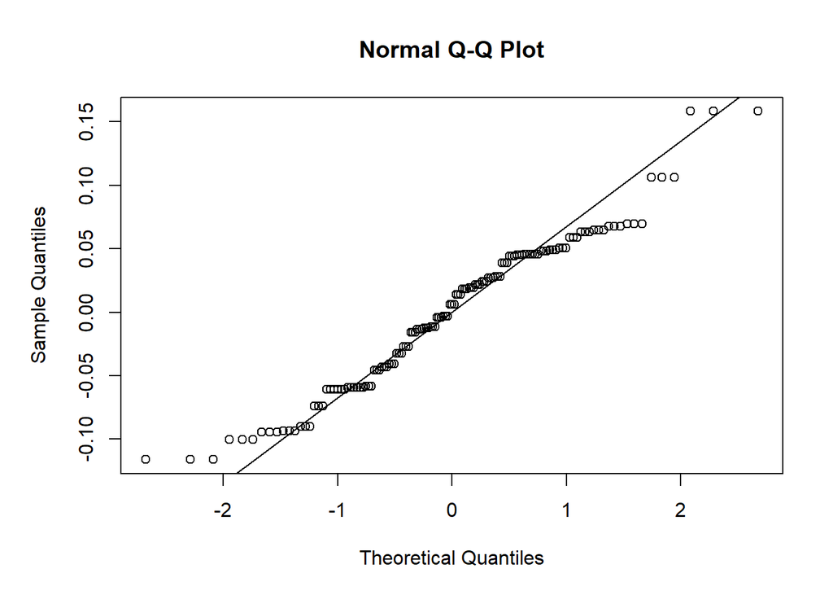

```r
ratmod2fina<- lmer(RatSurv~MeanFamGPD + (1|FemaleID)+ (1|MaleID), data=LarvByJarDatExpLarvae)
qqnorm(resid(ratmod2fina))
qqline(resid(ratmod2fina))
```

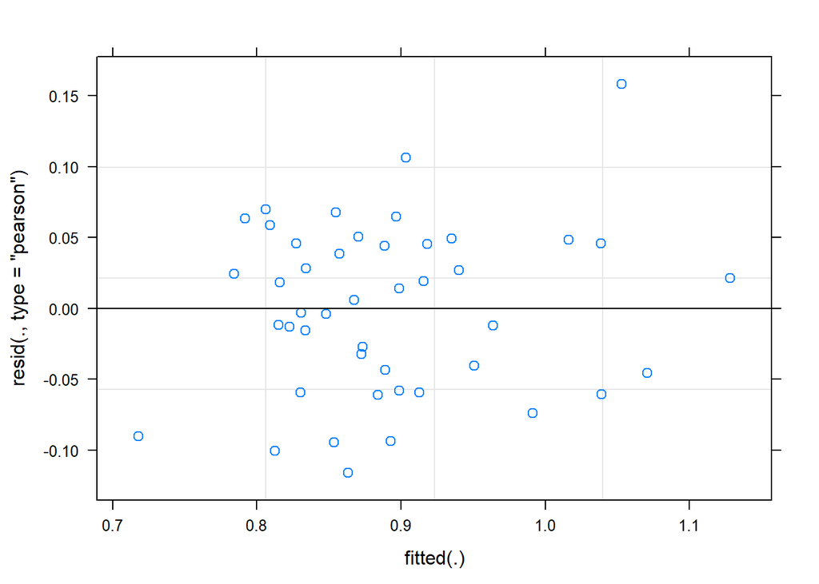

```r
plot(ratmod2fina)
```

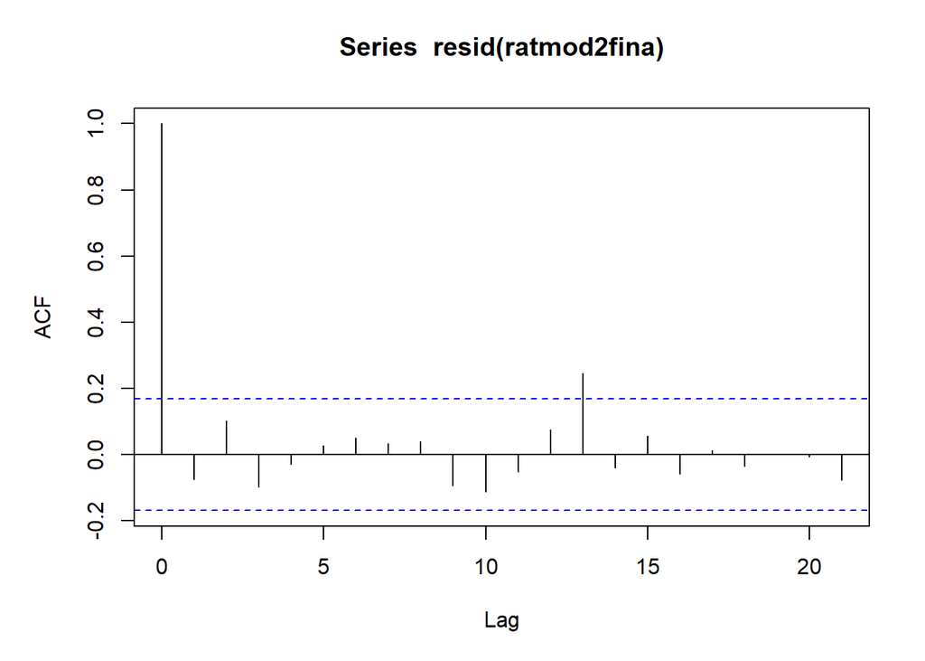

```r
acf(resid(ratmod2fina))
```

```r
summary(ratmod2fina)
```

```
## Linear mixed model fit by REML. t-tests use Satterthwaite's method [
## lmerModLmerTest]
## Formula: RatSurv ~ MeanFamGPD + (1 | FemaleID) + (1 | MaleID)
##    Data: LarvByJarDatExpLarvae
##
## REML criterion at convergence: -280.2
##
## Scaled residuals:
##     Min      1Q  Median      3Q     Max
## -1.7853 -0.6987  0.0926  0.7022  2.4358
##
## Random effects:
##  Groups   Name        Variance Std.Dev.
##  FemaleID (Intercept) 0.013153 0.11469
##  MaleID   (Intercept) 0.001964 0.04432
##  Residual             0.004224 0.06499
## Number of obs: 135, groups:  FemaleID, 15; MaleID, 11
##
## Fixed effects:
##             Estimate Std. Error       df t value Pr(>|t|)
## (Intercept)  1.19674    0.10900 75.23700  10.980  < 2e-16 ***
## MeanFamGPD  -0.07326    0.02469 92.64569  -2.967  0.00383 **
## ---
## Signif. codes:  0 '***' 0.001 '**' 0.01 '*' 0.05 '.' 0.1 ' ' 1
##
## Correlation of Fixed Effects:
##            (Intr)
## MeanFamGPD -0.953
```